# P3 MPDW - Regresi dengan Peubah Lag Soal 2

Naurah Aathirah Farid_M0401241037

2026-09-05

# Input Data

```r
year <- 1975:2014
sales <- c (11.7, 12.0, 12.3, 12.8, 13.1, 13.6, 13.9, 14.4, 14.7, 15.3,
            15.5, 15.8, 16.1, 16.6, 16.9, 16.7, 16.9, 17.4, 17.6, 17.9,
            18.0, 17.9, 18.0, 18.2, 18.2, 18.3, 18.6, 19.2, 19.3, 19.5,
            19.2, 19.3, 19.5, 20.0, 20.0, 19.9, 19.8, 19.9, 20.2, 21.0)
advertising <- c(9.4, 9.6, 10.0, 10.4, 10.8, 10.9, 11.7, 12.2, 12.5, 12.9,
                  13.0, 13.2, 13.8, 14.2, 14.6, 14.4, 15.0, 15.4, 15.7, 15.9,
                  15.9, 16.0, 16.3, 16.2, 16.8, 17.3, 17.6, 18.1, 18.3, 18.5,
                  18.7, 18.9, 19.2, 20.0, 20.0, 20.3, 20.4, 21.0, 21.5, 22.1)

dtsales <- data.frame(
  year = year,
  sales = sales,
  adv = advertising
)
head(dtsales)
```

```
##   year sales  adv
## 1 1975  11.7  9.4
## 2 1976  12.0  9.6
## 3 1977  12.3 10.0
## 4 1978  12.8 10.4
## 5 1979  13.1 10.8
## 6 1980  13.6 10.9
```

# Visualisasi Deret Waktu

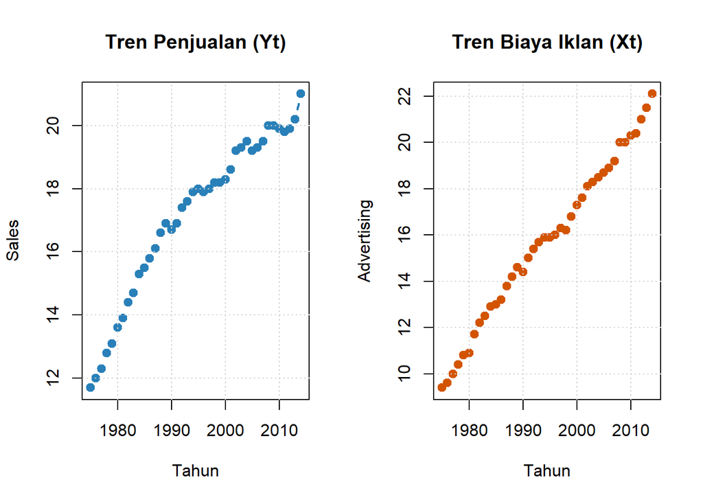

```r
par(mfrow = c(1, 2))
plot(dtsales$year, dtsales$sales, type = "b", pch = 19, col = "#2980B9", lwd = 2,
     xlab = "Tahun", ylab = "Sales", main = "Tren Penjualan (Yt)")
grid()

plot(dtsales$year, dtsales$adv, type = "b", pch = 19, col = "#D35400", lwd = 2,
     xlab = "Tahun", ylab = "Advertising", main = "Tren Biaya Iklan (Xt)")
grid()
```

```r
par(mfrow = c(1, 1))
```

# Pembagian Data

```r
train <- dtsales[1:32, ]
test  <- dtsales[33:40, ]

calc_mape <- function(actual, pred) { mean(abs((actual - pred) / actual)) * 100 }
calc_mad  <- function(actual, pred) { mean(abs(actual - pred)) }
calc_msd  <- function(actual, pred) { mean((actual - pred)^2) }
```

# Pencarian Lag Optimum ARDL

```r
opt_ardl <- ardlBoundOrders(
  data = train,
  formula = sales ~ adv,
  ic = "AIC",
  max.p = 5,
  max.q = 5
)
```

```r
opt_ardl
```

```
## $p
##   adv
## 1   5
##
## $q
## [1] 1
##
## $Stat.table
##            q = 1      q = 2     q = 3     q = 4     q = 5
## p = 1 -13.152246 -10.184497 -8.106966 -6.856816 -3.298772
## p = 2 -11.648161  -9.809908 -7.254672 -5.689361 -2.279843
## p = 3  -7.702995  -7.702995 -9.502040 -7.270320 -3.758204
## p = 4  -9.139679  -7.280046 -7.280046 -5.427058 -1.984810
## p = 5  -6.211749  -4.849111 -5.682300 -5.682300 -5.365467
##
## $min.Stat
## [1] -13.15225
```

```r
min_stat <- opt_ardl$min.Stat
mat_aic <- opt_ardl$Stat.table

pos_opt <- which(mat_aic == min_stat, arr.ind = TRUE)
best_p <- pos_opt[1, 1]  # Lag untuk adv (X)
best_q <- pos_opt[1, 2]  # Lag untuk sales (Y)

cat("Model ARDL Optimum terpilih: ARDL(", best_p, ",", best_q, ") dengan AIC =", min_stat, "\n")
```

```
## Model ARDL Optimum terpilih: ARDL( 1 , 1 ) dengan AIC = -13.15225
```

# Pendugaan Parameter Model Terbaik

```r
model_ardl_opt <- ardlDlm(formula = sales ~ adv, data = train, p = best_p, q = best_q)
summary(model_ardl_opt)
```

```
##
## Time series regression with "ts" data:
## Start = 2, End = 32
##
## Call:
## dynlm(formula = as.formula(model.text), data = data)
##
## Residuals:
##      Min       1Q   Median       3Q      Max
## -0.42212 -0.13934  0.00585  0.09313  0.33270
##
## Coefficients:
##             Estimate Std. Error t value Pr(>|t|)
## (Intercept)  1.30304    0.47500   2.743   0.0107 *
## adv.t        0.30844    0.15564   1.982   0.0578 .
## adv.1       -0.20644    0.17382  -1.188   0.2453
## sales.1      0.83951    0.09995   8.399  5.2e-09 ***
## ---
## Signif. codes:  0 '***' 0.001 '**' 0.01 '*' 0.05 '.' 0.1 ' ' 1
##
## Residual standard error: 0.1791 on 27 degrees of freedom
## Multiple R-squared:  0.9943, Adjusted R-squared:  0.9937
## F-statistic:  1575 on 3 and 27 DF,  p-value: < 2.2e-16
```

# Peramalan & Evaluasi Akurasi

```r
fore_ardl <- dLagM::forecast(
  model = model_ardl_opt,
  x     = test$adv,
  h     = nrow(test)
)

fore_ardl$forecasts
```

```
## [1] 19.52586 19.90030 20.04949 20.26727 20.41900 20.71081 20.98614 21.29912
```

```r
# Evaluasi akurasi data uji (testing)
mape_test <- calc_mape(test$sales, fore_ardl$forecasts)
mad_test  <- calc_mad(test$sales, fore_ardl$forecasts)
msd_test  <- calc_msd(test$sales, fore_ardl$forecasts)

# Evaluasi akurasi data latih (training)
gof_train  <- GoF(model_ardl_opt)
mape_train <- gof_train[1, "MAPE"] * 100

# Tabel Ringkasan Akurasi
eval_table <- data.frame(
  Model         = paste0("ARDL(", best_p, ",", best_q, ")"),
  MAPE_Training = paste0(round(mape_train, 4), "%"),
  MAPE_Testing  = paste0(round(mape_test, 4), "%"),
  MAD_Testing   = round(mad_test, 4),
  MSD_Testing   = round(msd_test, 4)
)

eval_table
```

```
##       Model MAPE_Training MAPE_Testing MAD_Testing MSD_Testing
## 1 ARDL(1,1)       0.8226%      1.9051%      0.3822       0.237
```

# Visuaslisasi Hasil Prediksi

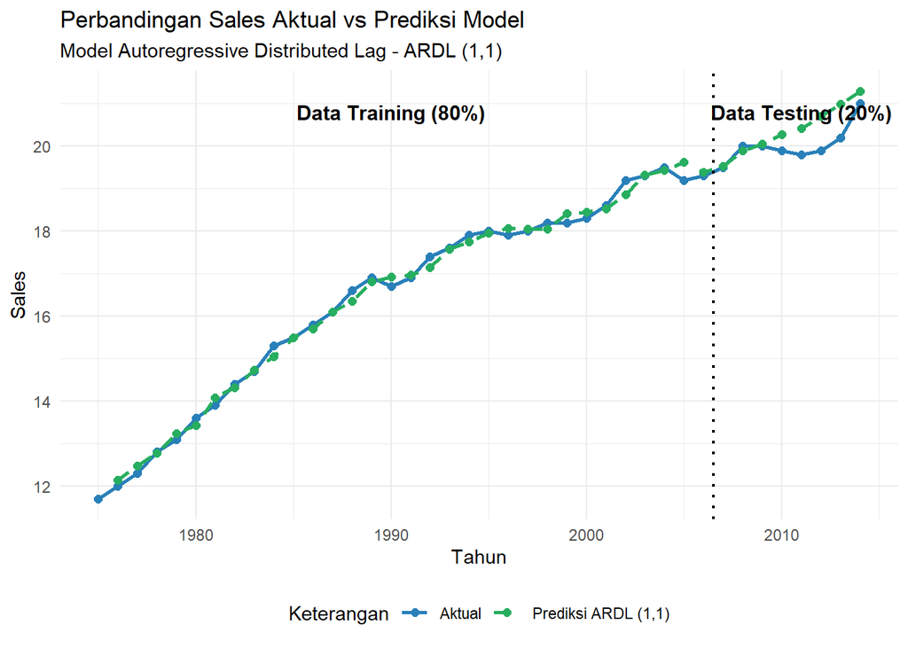

```r
pred_all <- c(NA, model_ardl_opt$model$fitted.values, fore_ardl$forecasts)

df_plot <- data.frame(
  Year     = dtsales$year,
  Aktual   = dtsales$sales,
  Prediksi = pred_all
)

ggplot(df_plot, aes(x = Year)) +
  geom_line(aes(y = Aktual, color = "Aktual"), linewidth = 1) +
  geom_point(aes(y = Aktual, color = "Aktual"), size = 2) +
  geom_line(aes(y = Prediksi, color = "Prediksi ARDL (1,1)"), linewidth = 1, linetype = "dashed") +
  geom_point(aes(y = Prediksi, color = "Prediksi ARDL (1,1)"), size = 2) +
  geom_vline(xintercept = 2006.5, linetype = "dotted", color = "black", linewidth = 0.8) +
  annotate("text", x = 1990, y = 20.8, label = "Data Training (80%)", fontface = "bold", size = 4) +
  annotate("text", x = 2011, y = 20.8, label = "Data Testing (20%)", fontface = "bold", size = 4) +
  scale_color_manual(values = c("Aktual" = "#2980B9", "Prediksi ARDL (1,1)" = "#27AE60")) +
  labs(title = "Perbandingan Sales Aktual vs Prediksi Model",
       subtitle = "Model Autoregressive Distributed Lag - ARDL (1,1)",
       x = "Tahun", y = "Sales", color = "Keterangan") +
  theme_minimal() +
  theme(legend.position = "bottom")
```

# Diagnostik Sisaan (Uji Asumsi Klasik)

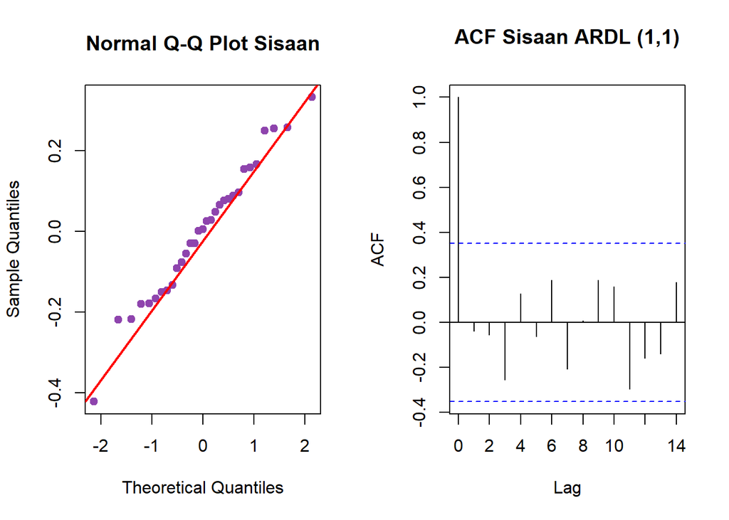

```r
sisaan <- residuals(model_ardl_opt$model)

# Visualisasi Sisaan
par(mfrow = c(1, 2))
qqnorm(sisaan, pch = 19, col = "#8E44AD", main = "Normal Q-Q Plot Sisaan")
qqline(sisaan, col = "red", lwd = 2)

acf(sisaan, main = "ACF Sisaan ARDL (1,1)")
```

```r
par(mfrow = c(1, 1))

# Uji Asumsi Klasik Formal
shapiro.test(sisaan)            # 1. Uji Normalitas
```

```
##
##  Shapiro-Wilk normality test
##
## data:  sisaan
## W = 0.98208, p-value = 0.8678
```

```r
dwtest(model_ardl_opt$model)    # 2. Uji Non-Autokorelasi (Durbin-Watson)
```

```
##
##  Durbin-Watson test
##
## data:  model_ardl_opt$model
## DW = 2.0428, p-value = 0.4089
## alternative hypothesis: true autocorrelation is greater than 0
```

```r
bgtest(model_ardl_opt$model)    # 3. Uji Non-Autokorelasi (Breusch-Godfrey)
```

```
##
##  Breusch-Godfrey test for serial correlation of order up to 1
##
## data:  model_ardl_opt$model
## LM test = 0.06059, df = 1, p-value = 0.8056
```

```r
bptest(model_ardl_opt$model)    # 4. Uji Homoskedastisitas (Breusch-Pagan)
```

```
##
##  studentized Breusch-Pagan test
##
## data:  model_ardl_opt$model
## BP = 2.5984, df = 3, p-value = 0.4578
```

# Pembahasan dan Kesimpulan

*Model Optimum Terpilih:*

Berdasarkan kriteria nilai AIC terendah pada fungsi ardlBoundOrders(), model terbaik yang terpilih adalah ARDL(1,1) dengan nilai AIC sebesar -13.1522. Persamaan dugaan model yang terbentuk adalah:
$$\hat{Y}_t = 1.3030 + 0.3084 X_t -
0.2064 X_{t-1} + 0.8395 Y_{t-1}$$

*Diagnostik Sisaan:* 1. Uji Durbin-Watson: Nilai $p\text{-value} = 0.4089 > 0.05$, menunjukkan sisaan bebas dari masalah autokorelasi. 2. Uji Breusch-Pagan: Nilai $p\text{-value} = 0.4578 > 0.05$, menunjukkan ragam sisaan homogen (memenuhi asumsi homoskedastisitas). 3. Uji Shapiro-Wilk: Nilai $p\text{-value} = 0.8678 > 0.05$, menunjukkan sisaan menyebar normal.

*Interpretasi Multiplier:*

Dampak Jangka Pendek (Impact Multiplier): Koefisien peubah $X_t$ adalah 0.3084. Artinya, kenaikan biaya iklan sebesar 1 satuan pada tahun berjalan akan meningkatkan penjualan secara langsung sebesar 0.3084 satuan pada tahun yang sama.

Dampak Jangka Panjang (Long-run Multiplier): Dihitung dengan rumus:
$$\text{Long-run Multiplier} =
\frac{\hat{\beta}_0 + \hat{\beta}_1}{1 - \hat{\phi}_1} = \frac{0.3084 +
(-0.2064)}{1 - 0.8395} = \frac{0.1020}{0.1605} \approx
0.6355$$

Artinya, jika penambahan biaya iklan sebesar 1 satuan dipertahankan terus-menerus setiap tahun, total akumulasi peningkatan penjualan dalam jangka panjang mencapai 0.6355 satuan.